# Baseball Project

Rebeca Berger

April 28, 2017

## Stat 370: Analyzing Baseball Data with R

### Introduction

This is my project for Stat 370: Intro to Statistical Computing and Modeling with Professor Sean Carver.

My project is about simulating baseball games using Markov chains and calculating transition matrices from the different states of a baseball inning. Using the 25 different states of a baseball game and existing game data, we are trying to answer the question “how many innings of data would you need in order to determine which team is playing the game?”

This information will be useful because it can help teams learn the strategy of other teams and their tendencies in certain game situations. Ultimately, we would like to convey its importance and market the findings to MLB teams.

This is an ongoing project that will continue beyond the semester. The following chunks are a small representation of the bigger project.

Source: All of the information used is from the book “Analyzing Baseball Data with R” by Max Marchi and Jim Albert.

## Value of Plays Using Run Expectancy

First, we will define the states of a baseball game. “000” means there are no runners on base at the time. “000 1” means no runners on base with one out. “100” means there is a runner on first base. “010” = runner on second. “001” = runner on third. “110” indicates runners on first and second, etc.

## Runs Contribution

In this next section, we will analyze the value of one player and compare his level of runs contribution to the rest of the players in the league. In this case, we still use Albert Pujols are our case study, one of the most powerful, dominant hitters in 2011.

```r
Roster <- read.csv("data/roster2011.csv")
albert.id <- subset(Roster, First.Name == "Albert" &
                     Last.Name == "Pujols")$Player.ID
albert.id <- as.character(albert.id)
albert <- subset(data2011, BAT_ID==albert.id)
albert <- subset(albert, BAT_EVENT_FL==TRUE)

albert[1:2, c("STATE", "NEW.STATE", "RUNS.VALUE")]
```

```
##      STATE NEW.STATE RUNS.VALUE
## 6556 100 1     000 3 -0.4960492
## 6574 001 2     001 3 -0.3173913
```

```r
albert$RUNNERS <- substr(albert$STATE, 1, 3)
table(albert$RUNNERS)
```

```
##
## 000 001 010 011 100 101 110 111
## 354  27  60   7 135  19  36  13
```

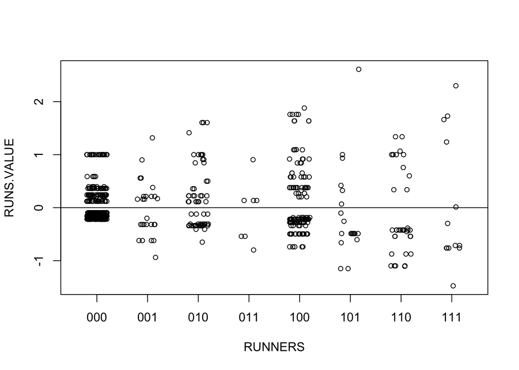

```r
with(albert, stripchart(RUNS.VALUE ~ RUNNERS, vertical=TRUE, jitter=0.2,
                        xlab="RUNNERS", method="jitter", pch=1, cex = 0.8))
abline(h=0)
```

```r
A.runs <- aggregate(albert$RUNS.VALUE, list(albert$RUNNERS), sum)
names(A.runs)[2] <- "RUNS"
A.PA <- aggregate(albert$RUNS.VALUE, list(albert$RUNNERS), length)
names(A.PA)[2] <- "PA"
A <- merge(A.PA, A.runs)
A
```

```
##   Group.1  PA       RUNS
## 1     000 354 10.7568515
## 2     001  27 -0.9417766
## 3     010  60  9.6399002
## 4     011   7 -0.5680439
## 5     100 135 14.2174870
## 6     101  19 -1.9853612
## 7     110  36 -4.5593651
## 8     111  13  0.6971003
```

```r
sum(A$RUNS)
```

```
## [1] 27.25679
```